# Método orientado a objetos

Hay distintas maneras de hacer gráficas dentro de Matplotlib.

## pyplot()

Podemos hacer esto:

```
plt.figure(figsize=(9,7),dpi=100)
plt.plot(time,velocity,'g-')
plt.plot(time,distance,'b-')
plt.xlabel('Tiempo (s)')
plt.ylabel('Velocidad (m/s) y Distancia (m)')
plt.grid(True)
```

[figure not shown]

## método orientado a objetos

Podemos hacer algo como esto:

```
fig, ax1 = plt.subplots()
ax1.set_ylabel("distance (m)")
ax1.set_xlabel("time")
ax1.plot(time, distance, "blue")
ax2 = ax1.twinx()
ax2.set_ylabel("velocity (m/s)")
ax2.set_xlabel("time")
ax2.plot(time, velocity, "green")
fig.set_size_inches(7,5)
fig.set_dpi(100)
```

[figure not shown]

Tiene mayor grado de personalización, al punto de poder modificar los valor entre los ejes coordenados, pero se requiere de mayor código.

## Implementación:

```python
#Librerias
import matplotlib.pyplot as plt
import numpy as np
```

```python
x = np.linspace(0,5,11)
y = x**2
```

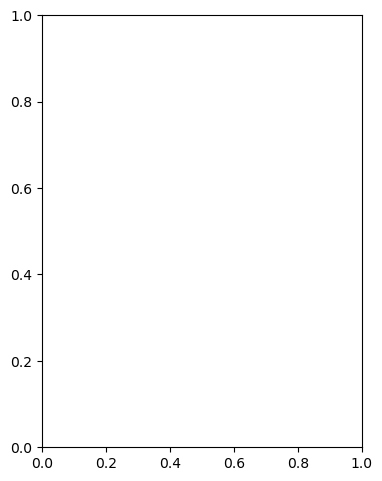

```python
#Orientado a objetos
#Creando FIGURA O lienzo donde van las gráficas
fig = plt.figure()  #Definir lienzo

#Graficas = Axes
#Es igual a mi objeto de tipo figura
axes = fig.add_axes([0.1,0.1,0.5,0.9])
#En nuestro lienzo acabo de crear una figura
```

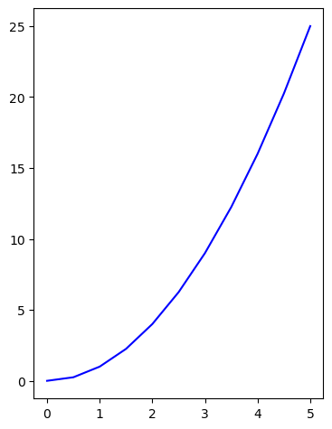

```python
#Orientado a objetos
#Creando FIGURA O lienzo donde van las gráficas
fig = plt.figure()  #Definir lienzo

#Graficas = Axes
#Es igual a mi objeto de tipo figura
axes = fig.add_axes([0.1,0.1,0.5,0.9])
#En nuestro lienzo acabo de crear una figura

#Que voy a hacer con el axes - Plot
axes.plot(x,y,'b')
fig.show()
```

La ventaja es cuando quiero hacer algo con más detalle y personalizado.

```python
#Orientado a objetos
#Creando FIGURA O lienzo donde van las gráficas
fig = plt.figure()  #Definir lienzo

#Graficas = Axes
#Es igual a mi objeto de tipo figura
axes = fig.add_axes([0.1,0.1,0.5,0.9])
#En nuestro lienzo acabo de crear una figura

#Que voy a hacer con el axes - Plot
axes.plot(x,y,'b')
fig.show()
```

[output not shown]

# Explicación:

```
axes = fig.add_axes([0.1,0.1,0.5,0.9])
```

- Los 2 primeros parametros `[0.1,0.1]` hacen referencia a la posición de la figura en el lienzo.
- Los 2 siguientes parametros `[0.5,0.9]` hacen referencia al tamaño que van a tener en el lienzo

#### Veamos un ejemplo

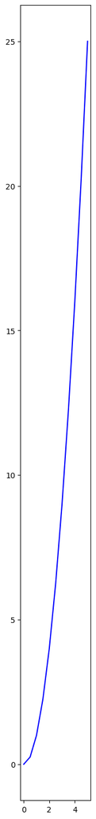

```python
#Orientado a objetos
#Creando FIGURA O lienzo donde van las gráficas
fig = plt.figure()  #Definir lienzo

#Graficas = Axes
#Es igual a mi objeto de tipo figura
axes = fig.add_axes([0.1,0.1,0.2,3])
#En nuestro lienzo acabo de crear una figura

#Que voy a hacer con el axes - Plot
axes.plot(x,y,'b')
fig.show()
```

# Explicación:

```
axes = fig.add_axes([0.1,0.1,0.2,3])
```

- Los 2 primeros parametros `[0.1,0.1]` hacen referencia a la posición de la figura en el lienzo.
- Los 2 siguientes parametros `[0.2,3]` hacen referencia al tamaño que van a tener en el lienzo
  - Aquí de ancho lo definí como `0.2`
  - El alto como `3`. El resultado es que hay una figura bastante alta

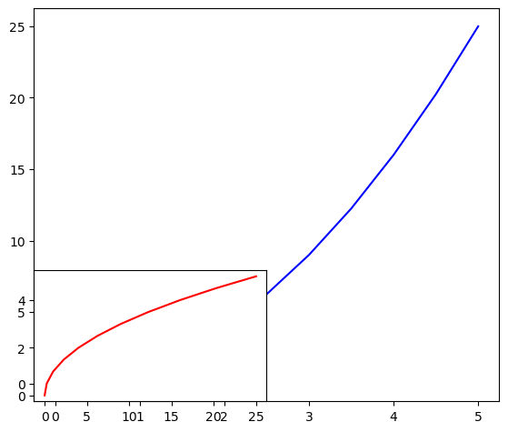

```python
#Orientado a objetos
#Creando FIGURA O lienzo donde van las gráficas
fig = plt.figure()  #Definir lienzo

#Graficas = Axes
#Es igual a mi objeto de tipo figura
axes = fig.add_axes([0.1,0.1,0.8,0.9])
#En nuestro lienzo acabo de crear una figura

#Ahora voy a especificar que no solo quiero un
#grafico
#2da gráfica
axes2 = fig.add_axes([0.1,0.1,0.4,0.3])

#Que voy a hacer con el axes - Plot
axes.plot(x,y,'b')      #Color blue
axes2.plot(y,x,'r')     #Color red

#Graficando
fig.show()
```

Como se puede observar, las gráficas no salen adecuadamente

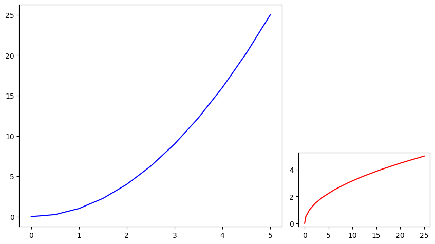

```python
#Orientado a objetos
#Creando FIGURA O lienzo donde van las gráficas
fig = plt.figure()  #Definir lienzo

#Graficas = Axes
#Es igual a mi objeto de tipo figura

#1a gráfica GRAFICA AZUL
axes = fig.add_axes([0.1,0.1,0.8,0.9])
#En nuestro lienzo acabo de crear una figura

#Ahora voy a especificar que no solo quiero un
#grafico

#2da gráfica GRAFICA ROJA
axes2 = fig.add_axes([.95,0.1,0.4,0.3])

#Que voy a hacer con el axes - Plot
axes.plot(x,y,'b')      #Color blue
axes2.plot(y,x,'r')     #Color red

#Graficando
fig.show()
```

# Explicación

Los 2 son objetos totalmente distintos, solo que reposan sobre un mismo lienzo. Con sus parámetros independientes.

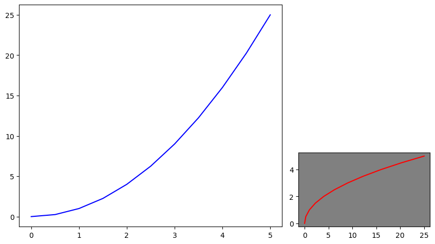

```python
#Orientado a objetos
#Creando FIGURA O lienzo donde van las gráficas
fig = plt.figure()  #Definir lienzo

#Graficas = Axes
#Es igual a mi objeto de tipo figura

#1a gráfica GRAFICA AZUL
axes = fig.add_axes([0.1,0.1,0.8,0.9])
#En nuestro lienzo acabo de crear una figura

#Ahora voy a especificar que no solo quiero un
#grafico

#2da gráfica GRAFICA ROJA
axes2 = fig.add_axes([.95,0.1,0.4,0.3])

#Que voy a hacer con el axes - Plot
axes.plot(x,y,'b')      #Color blue
axes2.plot(y,x,'r')     #Color red
#Alterando parametros de Figura2
axes2.set_facecolor('gray')

#Graficando
fig.show()
```

Cómo se puede deducir, el método por objectos es **Altamente personalizable** y nos ayuda a ajustar lo que realmente estemos buscando.

[figure not shown]

# Recursos adicionales:

[Pyplot vs Object Oriented](https://matplotlib.org/matplotblog/posts/pyplot-vs-object-oriented-interface/)